# Curso Derivados Facultad de Ciencias UNAM

## 6.2 Gamma

La gamma corresponde a la sensibilidad de la delta del derivado con respecto al precio del subyacente.
$$\begin{equation}
\Gamma = \frac{\partial^2 BS}{\partial S^2} = \frac{e^{-q\tau}N'(d_1)}{S\sigma\sqrt{\tau}}.
\end{equation}$$
Este valor representa que tanto se debe de reajustar la delta para hacer el delta-hedge.

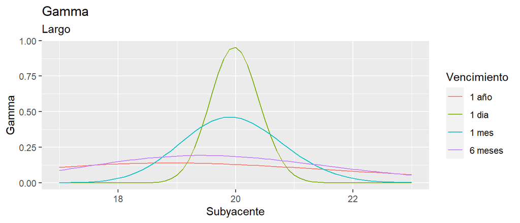

```r
# Gamma
Gamma <- function(S,K,tau,r,q,sigma){
  d1 <- (log(S/K)+(r-q-.5*sigma^2)*tau)/(sigma*sqrt(tau))
  griega <- exp(-q*tau)*dnorm(d1)/(S*sigma*sqrt(tau))
  return(griega)
}

tipo <- 1
Grafica <- data.frame(S=rep(S,length(tau)),Tau=rep(tau,each=length(S)))
Grafica[,"Gamma"] <- mapply(Gamma,Grafica$S,K,Grafica$Tau,r,q,sigma)
Grafica <- left_join(Grafica,tau_aux,by = "Tau")
Grafica$Tau <- NULL
ggplot(Grafica,aes(x=S,y=Gamma,color=Vencimiento)) +
  geom_line() +
  labs(title="Gamma",subtitle = "Largo",x="Subyacente")
```

## 6.3 Vega

La vega corresponde a la sensibilidad del derivado con respecto al parámetro de la volatilidad.
$$\begin{equation}
\nu = \frac{\partial BS}{\partial \sigma} = Se^{-q\tau}N'(d_1)\sqrt{\tau}.
\end{equation}$$
Este valor representa los cambios en el precio debido a cambios en la volatilidad.

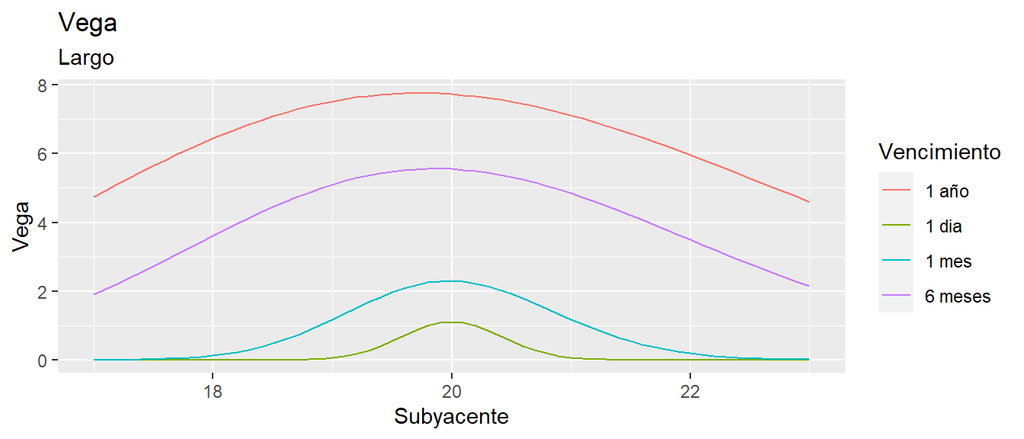

```r
# Vega
Vega <- function(S,K,tau,r,q,sigma){
  d1 <- (log(S/K)+(r-q-.5*sigma^2)*tau)/(sigma*sqrt(tau))
  griega <- S*exp(-q*tau)*dnorm(d1)*sqrt(tau)
  return(griega)
}

tipo <- 1
Grafica <- data.frame(S=rep(S,length(tau)),Tau=rep(tau,each=length(S)))
Grafica[,"Vega"] <- mapply(Vega,Grafica$S,K,Grafica$Tau,r,q,sigma)
Grafica <- left_join(Grafica,tau_aux,by = "Tau")
Grafica$Tau <- NULL
ggplot(Grafica,aes(x=S,y=Vega,color=Vencimiento)) +
  geom_line() +
  labs(title="Vega",subtitle = "Largo",x="Subyacente")
```

## 6.4 Theta

La theta corresponde a la sensibilidad del derivado con respecto al vencimiento.
$$\begin{equation}
\Theta = \frac{\partial BS}{\partial \tau} = -\frac{e^{-q\tau}SN'(d_1)\sigma}{2\sqrt{\tau}}-\phi rKe^{-r\tau}N(\phi d_2)+\phi qSe^{-q\tau}N(\phi d_1).
\end{equation}$$
Este valor representa los cambios en el precio a medida que la opción se acerca a vencimiento.

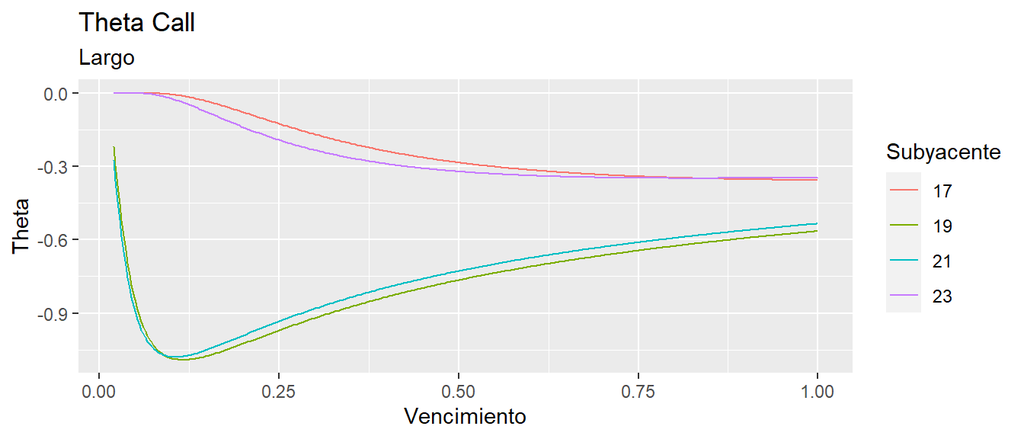

```r
# Theta
Theta <- function(S,K,tau,r,q,sigma,tipo){
  d1 <- (log(S/K)+(r-q-.5*sigma^2)*tau)/(sigma*sqrt(tau))
  d2 <- d1-sigma*sqrt(tau)
  griega <- -.5*exp(-q*tau)*S*dnorm(d1)*sigma/sqrt(tau)
            -tipo*r*K*exp(-r*tau)*pnorm(tipo*d2)
            +tipo*q*S*exp(-q*tau)*pnorm(tipo*d1)
  return(griega)
}

S <- c(17,19,21,23)
tau <- seq(7,360)/360

tipo <- 1
Grafica <- data.frame(S=rep(S,length(tau)),Tau=rep(tau,each=length(S)))
Grafica[,"Theta"] <- mapply(Theta,Grafica$S,K,Grafica$Tau,r,q,sigma,tipo)
Grafica$S <- factor(Grafica$S)
ggplot(Grafica,aes(x=Tau,y=Theta,color=S)) +
  geom_line() +
  labs(title="Theta Call",subtitle = "Largo",color="Subyacente",x="Vencimiento")
```

[figure not shown]

```r
tipo <- -1
Grafica <- data.frame(S=rep(S,length(tau)),Tau=rep(tau,each=length(S)))
Grafica[,"Theta"] <- mapply(Theta,Grafica$S,K,Grafica$Tau,r,q,sigma,tipo)
Grafica$S <- factor(Grafica$S)
ggplot(Grafica,aes(x=Tau,y=Theta,color=S)) +
  geom_line() +
  labs(title="Theta Put",subtitle = "Largo",color="Subyacente",x="Vencimiento")
```

## 6.5 Aproximaciones con Griegas

Otro uso de las griegas es realizar aproximaciones del precio o del PnL (Profit & Loss).

Aplicando series de Taylor al precio de una opción $V(t)$ obtenemos
$$\begin{equation}
V(S+\delta S,t+ \delta t) = V(S,t)+\Delta\delta S+\frac{1}{2}\Gamma\delta S^2+\Theta\delta t+o(\delta S,\delta t)
\end{equation}$$

Ahora tomemos un portafolio el cual consta del derivado $V(t)$ y $M$ unidades del subyacente $S$, i.e.
$$\begin{equation}
P(S,t) = V(S,t) + M\cdot S,
\end{equation}$$
de modo que
$$\begin{equation}
P(S+\delta S,t+ \delta t) = P(S,t)+(M+\Delta)\delta S+\frac{1}{2}\Gamma\delta S^2+\Theta\delta t+o(\delta S,\delta t).
\end{equation}$$

El PnL a tiempo $t+\delta t$ puede ser calculado como
$$\begin{equation}
PnL_{t+\delta t}=P(S+\delta S,t+ \delta t)-P(S,t) = (M+\Delta)\delta S+\frac{1}{2}\Gamma\delta S^2+\Theta\delta t+o(\delta S,\delta t).
\end{equation}$$
En el caso de un portafolio delta hedged se tendría $M=-\Delta$, con lo cual se tendría
$$\begin{equation}
PnL_{t+\delta t}=\frac{1}{2}\Gamma\delta S^2+\Theta\delta t+o(\delta S,\delta t).
\end{equation}$$

El razonamiento anterior se puede extender para incluir más griegas y hacer *vega-hedge*.

## 6.6 Ejercicios

**Ejercicio** Exprese la $\Delta_{\text{Call}}$ en términos de $\Delta_{\text{Put}}$.

**Ejercicio** Demuestre que la $\Gamma_{\text{Call}}=\Gamma_{\text{Put}}$ y que $\nu_{\text{Call}}=\nu_{\text{Put}}$.

**Ejercicio (Forward Delta)** Demuestre que el número de forwards largos para cubrir una opción corta es $\phi N(\phi d_1)$.

**Ejercicio (Simetría Put-Call)** Definimos el precio forward $F(\tau)$ como el strike $K$ tal que el precio del forward es igual a cero. Demuestre que $BS(S,K,\tau,r,q,\sigma,1)=\frac{K}{F(\tau)}BS\left(S,\frac{F^2(\tau)}{K},\tau,r,q,\sigma,-1\right)$.

**Ejercicio (Delta ATM)** Encuentre el strike $K$ tal que $\Delta_{\text{Call}}+\Delta_{\text{Put}}=0$

**Ejercicio (Strike en términos de Delta)** Exprese el strike $K$ en términos de delta $\Delta=\phi N(\phi d_1)$

**Ejercicio** Grafique la delta, gamma y vega con respecto al tiempo y la theta con respecto al subyacente e interprete las gráficas.

## 6.7 Bibliografía

- Hull, J. (2018) *Options, Futures and other Derivative Securities*, 10th edition, Pearson, New York.
- Shreve, S. (2004) *Stochastic Calculus for Finance II: Continuous-Time Models*, Springer-Verlag, New York.
- Wystup, U. (2017) *FX Options and Structure Products*, Wiley, United Kingdom.